# Pipelines For Data Analysis In R, part 3

曾意儒 Yi-Ju Tseng

### 資料分析步驟

- 資料匯入
- 資料清洗處理並轉換為Tidy data
- **資料分析**
- **資料呈現與視覺化**

## 資料分析大綱

- 什麼是探索式資料分析
- 量化的分析方式
- dplyr

## 什麼是探索式資料分析

- 探索式資料分析 (**E**xploratory **D**ata **A**nalysis)
- 在資料量 大/雜/髒 的時候，探索式資料分析非常重要
- 運用**視覺化**、**基本的統計**等工具，反覆的探索**資料特性**，獲取資料所包含的資訊、結構和特點
- 在進行複雜或嚴謹的分析之前，必須要對資料有更多認識，才能訂定**對的資料分析方向**
- 通常**不需要**嚴謹的假設和細節呈現

### 探索式資料分析

- 分析各變數間的**關聯性**，看是否有預料之外的有趣發現
- 觀察資料內容是否符合預期，若否，檢查資料**是否有誤**
- 檢查資料是否符合分析前的假設

透過探索性分析來**調整分析的方向**，減少因分析方向錯誤所造成的時間浪費。

### 探索式資料分析

- 圖形化Graphical
  - 單變量Univariate
  - 雙變量Bivariate
  - 多變量Multivariate
- 量化Quantitative
  - 單變量Univariate
  - 雙變量Bivariate
  - 多變量Multivariate

### 圖形化的分析

包括做圖與列表，將會在下章節介紹，本章節著重於量化的分析方式。

### 量化的分析方式: 單變量

資料初步統計，量化的分析方式可包含

- 計算集中趨勢
  - 平均值 Mean `mean()`
  - 中位數 Median `median()`
  - 眾數 Mode，R無內建函數，可直接用`table()`找出現次數最多的資料

### 量化的分析方式: 單變量-集中趨勢

```r
mean(iris$Sepal.Length)
```

```
[1] 5.843333
```

```r
median(iris$Sepal.Length)
```

```
[1] 5.8
```

```r
table(iris$Species)
```

```
    setosa versicolor  virginica
        50         50         50
```

### 量化的分析方式: 單變量

資料初步統計，量化的分析方式可包含

- 計算資料分散程度
  - 最小值 Min `min()`
  - 最大值 Max `max()`
  - 範圍 Range `range()`
  - 四分位差 Quartiles `quantile()`
  - 變異數 Variance `var()`
  - 標準差 Standard deviation `sd()`

### 量化的分析方式: 單變量-分散程度

```r
min(iris$Sepal.Length)
```

```
[1] 4.3
```

```r
max(iris$Sepal.Length)
```

```
[1] 7.9
```

```r
range(iris$Sepal.Length)
```

```
[1] 4.3 7.9
```

### 量化的分析方式: 單變量

```r
quantile(iris$Sepal.Length)
```

```
  0%  25%  50%  75% 100%
 4.3  5.1  5.8  6.4  7.9
```

```r
var(iris$Sepal.Length)
```

```
[1] 0.6856935
```

```r
sd(iris$Sepal.Length)
```

```
[1] 0.8280661
```

### 量化的分析方式: 雙變量

- 列聯表 Crosstabs `table()`, `prop.table()`
- 相關性 Correlation `cor()`

### 量化的分析方式: 雙變量-列聯表

汽缸的數目與自手排的關係

```r
table(mtcars$cyl,mtcars$am)
```

```
     0  1
  4  3  8
  6  4  3
  8 12  2
```

### 量化的分析方式: 雙變量-相關性

油耗跟馬力的關聯性（相關係數）

```r
cor(mtcars$mpg,mtcars$hp)
```

```
[1] -0.7761684
```

### 量化的分析方式 w/ R

- 大多可用R的內建函數完成計算
- 但是在探索式分析時，常常需要**資料分組**
  - 觀察**男性**和**女性**的血壓差異
  - **A隊**與**B隊**的三分球命中率差異
  - **中鋒**和**後衛**的助攻次數
  - …等
- 若只用基本的內建函數計算，相當耗時
  - `data.table`和`dplyr` packages可以快速完成**分組分析**!

### data.table 參考文件與資源

- [官網](https://github.com/Rdatatable/data.table/wiki)
- 指令全集[The data.table R package cheat sheet](https://s3.amazonaws.com/assets.datacamp.com/img/blog/data+table+cheat+sheet.pdf)
- [A data.table R tutorial by DataCamp](https://www.datacamp.com/community/tutorials/data-table-r-tutorial#gs.vzMYa_k)
- DataCamp [互動式教學課程](https://www.datacamp.com/courses/data-table-data-manipulation-r-tutorial)

## dplyr

- [Hadley Wickham](http://hadley.nz/)開發
- 使用以下函數分析整理資料：
  - `select()`: 選要分析的欄位，欄位子集 (Column)
  - `filter()`: 選要分析的觀察值，觀察值子集 (Row)
  - `mutate()`: 增加新欄位
  - `summarise()`: 計算統計值

## dplyr

- 使用以下函數分析整理資料：
  - `group_by()`: 分組依據
  - `arrange()`: 觀察值排序
  - `rename()`: 欄位重新命名
  - `%>%`: the “pipe” operator 連結上數函式，將所有函式計算串在一起執行

### dplyr

如要使用必須安裝並載入`dplyr` package

```r
install.packages("dplyr") ##安裝
```

```r
library(dplyr) ##載入
```

以上述NBA資料為例，首先先讀入資料

```r
library(SportsAnalytics)
NBA1516<-fetch_NBAPlayerStatistics("15-16")
```

### 欄位(Column)子集 select()

- 針對欄位 (Column)做子集
- `select(資料名稱,欄位條件1,欄位條件2,...)`
- 條件1與條件2是使用**或**的連結概念

### 欄位(Column)子集 select()

- `dplyr`提供幾個方便篩選名稱的函式：
  - `starts_with()`
  - `ends_with()`
  - `contains()`
  - `matches()`: matches a regular expression
  - `num_range()`: num_range(“x”, 8:11).
  - `one_of()`: variables in character vector
  - `everything()`

詳細說明可在R執行視窗中輸入`?select_helpers`查看。

### 欄位(Column)子集 select()

篩選欄位名稱為`Name`、開頭是`Threes`或是開頭是`FieldGoals`的欄位

```r
##等於NBA1516[,c("Name","ThreesMade","ThreesAttempted",
##   "FieldGoalsMade","FieldGoalsAttempted")]
select1<-
    select(NBA1516,Name,starts_with("Threes"),
            starts_with("FieldGoals"))
head(select1)
```

| Name | ThreesMade | ThreesAttempted | FieldGoalsMade | FieldGoalsAttempted |
| --- | --- | --- | --- | --- |
| Quincy Acy | 19 | 49 | 119 | 214 |

### 欄位(Column)子集 select()

若想篩選欄位`Name`到欄位`FieldGoalsMade`間的所有欄位，但不想要`GamesPlayed`欄位

- 用`:`串連欄位名稱
- 用`-`去除不要的欄位

```r
##等同於NBA1516[,c(2:4,612)]
select3<-
    select(NBA1516,Name:FieldGoalsMade,-GamesPlayed)
head(select3,3)
```

| Name | Team | Position | TotalMinutesPlayed | FieldGoalsMade |
| --- | --- | --- | --- | --- |
| Quincy Acy | SAC | SF | 877 | 119 |
| Jordan Adams | MEM | SG | 15 | 2 |
| Steven Adams | OKL | C | 2019 | 261 |

### 觀察值(Row)子集 filter()

- 是針對列 (Row)做子集
- `filter(資料名稱,篩選條件1,篩選條件2)`篩選條件們是用**且**的邏輯串連
- **出場分鐘數超過2850分鐘**的球員資料，可輸入下列指令

```r
##等於NBA1516[NBA1516$TotalMinutesPlayed>2850,]
filter(NBA1516,TotalMinutesPlayed>2850)
```

| League | Name | Team | Position | GamesPlayed | TotalMinutesPlayed | FieldGoalsMade | FieldGoalsAttempted | ThreesMade | ThreesAttempted | FreeThrowsMade | FreeThrowsAttempted | OffensiveRebounds | TotalRebounds | Assists | Steals | Turnovers | Blocks | PersonalFouls | Disqualifications | TotalPoints | Technicals | Ejections | FlagrantFouls | GamesStarted |
| --- | --- | --- | --- | --- | --- | --- | --- | --- | --- | --- | --- | --- | --- | --- | --- | --- | --- | --- | --- | --- | --- | --- | --- | --- |
| NBA | Trevor Ariza | HOU | SF | 81 | 2860 | 357 | 858 | 185 | 497 | 126 | 161 | 67 | 366 | 188 | 161 | 113 | 26 | 177 | 0 | 1025 | 2 | 0 | 0 | 81 |
| NBA | James Harden | HOU | SG | 82 | 3121 | 710 | 1617 | 236 | 656 | 720 | 837 | 63 | 502 | 612 | 138 | 374 | 51 | 229 | 1 | 2376 | 2 | 0 | 0 | 82 |
| NBA | Gordon Hayward | UTA | SG | 80 | 2889 | 521 | 1202 | 143 | 410 | 393 | 477 | 61 | 397 | 296 | 95 | 202 | 27 | 183 | 0 | 1578 | 0 | 0 | 0 | 80 |
| NBA | Kyle Lowry | TOR | PG | 77 | 2853 | 512 | 1198 | 212 | 546 | 398 | 491 | 55 | 365 | 494 | 158 | 225 | 34 | 211 | 1 | 1634 | 9 | 0 | 0 | 77 |
| NBA | Khris Middleton | MIL | SF | 79 | 2855 | 507 | 1144 | 143 | 362 | 277 | 312 | 45 | 301 | 331 | 131 | 180 | 19 | 204 | 1 | 1434 | 5 | 0 | 0 | 79 |
| NBA | Marcus Morris | DET | SF | 80 | 2852 | 410 | 945 | 108 | 297 | 203 | 271 | 91 | 404 | 201 | 67 | 140 | 23 | 170 | 1 | 1131 | 11 | 0 | 0 | 80 |
| NBA | Kemba Walker | CHA | PG | 81 | 2885 | 568 | 1332 | 182 | 490 | 371 | 438 | 56 | 358 | 421 | 127 | 171 | 39 | 111 | 0 | 1689 | 5 | 0 | 0 | 81 |

### 觀察值(Row)子集 filter()

也可選擇隊伍名稱為"BOS"或"SAN"的球員資料

```r
##等於NBA1516[NBA1516$Team %in% c("BOS","SAN"),]
filter(NBA1516,Team %in% c("BOS","SAN"))
```

| League | Name | Team | Position | GamesPlayed | TotalMinutesPlayed | FieldGoalsMade | FieldGoalsAttempted | ThreesMade | ThreesAttempted | FreeThrowsMade | FreeThrowsAttempted | OffensiveRebounds | TotalRebounds | Assists | Steals | Turnovers | Blocks | PersonalFouls | Disqualifications | TotalPoints | Technicals | Ejections | FlagrantFouls | GamesStarted |
| --- | --- | --- | --- | --- | --- | --- | --- | --- | --- | --- | --- | --- | --- | --- | --- | --- | --- | --- | --- | --- | --- | --- | --- | --- |
| NBA | Lamarcu Aldridge | SAN | PF | 74 | 2260 | 536 | 1045 | 0 | 16 | 259 | 302 | 175 | 631 | 110 | 38 | 99 | 81 | 151 | 0 | 1331 | 0 | 0 | 0 | 74 |
| NBA | Kyle Anderson | SAN | SF | 78 | 1247 | 138 | 296 | 12 | 37 | 62 | 83 | 25 | 245 | 123 | 60 | 59 | 29 | 97 | 0 | 350 | 0 | 0 | 0 | 11 |
| NBA | Matt Bonner | SAN | C | 30 | 210 | 29 | 58 | 15 | 35 | 3 | 4 | 3 | 27 | 9 | 6 | 3 | 1 | 16 | 0 | 76 | 0 | 0 | 0 | 2 |
| NBA | Avery Bradley | BOS | PG | 76 | 2536 | 456 | 1018 | 147 | 406 | 96 | 123 | 48 | 220 | 158 | 117 | 109 | 19 | 164 | 2 | 1155 | 0 | 0 | 0 | 72 |
| NBA | Rasual Butler | SAN | SF | 46 | 432 | 49 | 105 | 15 | 49 | 11 | 16 | 3 | 56 | 24 | 13 | 8 | 23 | 11 | 0 | 124 | 0 | 0 | 0 | 0 |
| NBA | Coty Clarke | BOS | NA | 4 | 8 | 2 | 4 | 2 | 2 | 0 | 0 | 0 | 1 | 0 | 0 | 1 | 0 | 0 | 0 | 6 | 0 | 0 | 0 | 0 |

### 觀察值(Row)子集 filter()

也可使用 `&` 和 `|`等符號串連邏輯

```r
filter(NBA1516,
       FieldGoalsMade/FieldGoalsAttempted>0.7
           &GamesPlayed>30)
```

| League | Name | Team | Position | GamesPlayed | TotalMinutesPlayed | FieldGoalsMade | FieldGoalsAttempted | ThreesMade | ThreesAttempted | FreeThrowsMade | FreeThrowsAttempted | OffensiveRebounds | TotalRebounds | Assists | Steals | Turnovers | Blocks | PersonalFouls | Disqualifications | TotalPoints | Technicals | Ejections | FlagrantFouls | GamesStarted |
| --- | --- | --- | --- | --- | --- | --- | --- | --- | --- | --- | --- | --- | --- | --- | --- | --- | --- | --- | --- | --- | --- | --- | --- | --- |
| NBA | Deandre Jordan | LAC | C | 77 | 2600 | 357 | 507 | 0 | 1 | 266 | 619 | 267 | 1059 | 90 | 52 | 107 | 176 | 207 | 1 | 980 | 10 | 0 | 0 | 77 |

### dplyr 子集練習

- 讀入NBA資料

```r
library(SportsAnalytics)
library(dplyr)
NBA1516<-fetch_NBAPlayerStatistics("15-16")
```

- 試著用dplyr語法篩選出所有**助攻數(Assists)超過100**且**抄截數大於20**的球員資料
- 只留下Name Team Position GamesPlayed TotalMinutesPlayed Assists Steals 七個欄位

### 增加新欄位 mutate()

- 新增新欄位`FGRate`，欄位值為`FieldGoalsMade/FieldGoalsAttempted`

```r
mutate1<-
    mutate(NBA1516,
           FGRate=FieldGoalsMade/FieldGoalsAttempted)
mutate1$FGRate[1:5]
```

```
[1] 0.5560748 0.3333333 0.6126761 0.4430538 0.4777070
```

### 計算統計值 summarise()

- **球員個數**、**不重複的隊伍數**以及**不重複的守備位置數**等
- n(), n_distinct()

```r
summarise(NBA1516,
          nPlayer=n(),
          nTeam=n_distinct(Team),
          nPos=n_distinct(Position))
```

```
  nPlayer nTeam nPos
1     476    31    6
```

### 計算統計值 summarise()

- 通常會與其他功能合併使用
- 計算**出場分鐘數大於2500分鐘**的**球員個數**、**平均投進的兩分球數**以及**平均投出的兩分球數**

```r
filter1<-filter(NBA1516,TotalMinutesPlayed>2500)
summarise(filter1,
          nPlayer=n(),
          meanFGMade=mean(FieldGoalsMade),
          meanFGAtt=mean(FieldGoalsAttempted))
```

```
  nPlayer meanFGMade meanFGAtt
1      40        512    1120.6
```

### dplyr filter()+summarise() 練習

- 讀入NBA資料

```r
library(SportsAnalytics)
library(dplyr)
NBA1516<-fetch_NBAPlayerStatistics("15-16")
```

- 試著用dplyr語法篩選出所有**助攻數(Assists)超過100**且**抄截數大於20**的球員資料
- 計算這些球員的**平均出場數GamesPlayed**，**平均出場分鐘數TotalMinutesPlayed**

### pipe %>%

- 直接用**pipe**符號`%>%`將指令串連，減少暫存物件（filter1）的生成

```r
filter(NBA1516,TotalMinutesPlayed>2500) %>%
    summarise(nPlayer=n(),
        meanFGMade=mean(FieldGoalsMade),
        meanFGAtt=mean(FieldGoalsAttempted))
```

```
  nPlayer meanFGMade meanFGAtt
1      40        512    1120.6
```

### 分組 group_by()

- 設定分組依據
- 與`summarise()`函式合併使用
- 計算各**隊**（以Team作為分組依據）的**球員數**、**平均投進的兩分球數**以及**平均投出的兩分球數**

```r
group_by(NBA1516,Team)%>%
    summarise(nPlayer=n(),
        meanFGMade=mean(FieldGoalsMade),
        meanFGAtt=mean(FieldGoalsAttempted))
```

| Team | nPlayer | meanFGMade | meanFGAtt |
| --- | --- | --- | --- |
| ATL | 15 | 215.0000 | 471.1333 |
| BOS | 15 | 208.6000 | 475.0667 |
| BRO | 16 | 181.0625 | 395.8750 |
| CHA | 14 | 199.1429 | 450.7857 |

### 分組 group_by()

- 可設定**多個**分組依據
- 計算各**隊**各**守備位置**（以Team和Position作為分組依據）的**球員數**、**平均投進的兩分球數**以及**平均投出的兩分球數**

```r
group_by(NBA1516,Team,Position)%>%
  summarise(nPlayer=n(),
        meanFGMade=mean(FieldGoalsMade),
        meanFGAtt=mean(FieldGoalsAttempted))
```

| Team | Position | nPlayer | meanFGMade | meanFGAtt |
| --- | --- | --- | --- | --- |
| ATL | C | 1 | 11.0000 | 19.0000 |
| ATL | PF | 6 | 247.3333 | 515.6667 |
| ATL | PG | 2 | 381.5000 | 884.0000 |

### 排序 arrange()

排序功能，預設為**遞增排序**

```r
arrange(NBA1516,TotalMinutesPlayed)
```

| League | Name | Team | Position | GamesPlayed | TotalMinutesPlayed | FieldGoalsMade | FieldGoalsAttempted | ThreesMade | ThreesAttempted | FreeThrowsMade | FreeThrowsAttempted | OffensiveRebounds | TotalRebounds | Assists | Steals | Turnovers | Blocks | PersonalFouls | Disqualifications | TotalPoints | Technicals | Ejections | FlagrantFouls | GamesStarted |
| --- | --- | --- | --- | --- | --- | --- | --- | --- | --- | --- | --- | --- | --- | --- | --- | --- | --- | --- | --- | --- | --- | --- | --- | --- |
| NBA | J.j. O'brien | UTA | SF | 1 | 2 | 0 | 1 | 0 | 0 | 0 | 0 | 0 | 0 | 0 | 0 | 0 | 0 | 0 | 0 | 0 | 0 | 0 | 0 | 0 |
| NBA | Rakeem Christmas | IND | PF | 1 | 6 | 2 | 2 | 0 | 0 | 0 | 0 | 1 | 1 | 0 | 0 | 0 | 0 | 1 | 0 | 4 | 0 | 0 | 0 | 0 |
| NBA | Th Antetokounmpo | NYK | SF | 3 | 7 | 3 | 4 | 0 | 1 | 0 | 0 | 0 | 1 | 0 | 0 | 0 | 0 | 2 | 0 | 6 | 0 | 0 | 0 | 0 |
| NBA | Sam Dekker | HOU | SF | 3 | 7 | 0 | 0 | 0 | 0 | 0 | 0 | 0 | 1 | 0 | 1 | 0 | 0 | 0 | 0 | 0 | 0 | 0 | 0 | 0 |
| NBA | Coty Clarke | BOS | NA | 4 | 8 | 2 | 4 | 2 | 2 | 0 | 0 | 0 | 1 | 0 | 0 | 1 | 0 | 0 | 0 | 6 | 0 | 0 | 0 | 0 |
| NBA | Jordan Adams | MEM | SG | 2 | 15 | 2 | 6 | 0 | 1 | 3 | 5 | 0 | 2 | 3 | 3 | 2 | 0 | 2 | 0 | 7 | 0 | 0 | 0 | 0 |

### 遞減排序 arrange()

使用`desc()`將要**遞減排序**的變數包起來，就可以遞減排序

```r
arrange(NBA1516,
        desc(TotalMinutesPlayed),
        desc(GamesPlayed))
```

| League | Name | Team | Position | GamesPlayed | TotalMinutesPlayed | FieldGoalsMade | FieldGoalsAttempted | ThreesMade | ThreesAttempted | FreeThrowsMade | FreeThrowsAttempted | OffensiveRebounds | TotalRebounds | Assists | Steals | Turnovers | Blocks | PersonalFouls | Disqualifications | TotalPoints | Technicals | Ejections | FlagrantFouls | GamesStarted |
| --- | --- | --- | --- | --- | --- | --- | --- | --- | --- | --- | --- | --- | --- | --- | --- | --- | --- | --- | --- | --- | --- | --- | --- | --- |
| NBA | James Harden | HOU | SG | 82 | 3121 | 710 | 1617 | 236 | 656 | 720 | 837 | 63 | 502 | 612 | 138 | 374 | 51 | 229 | 1 | 2376 | 2 | 0 | 0 | 82 |
| NBA | Gordon Hayward | UTA | SG | 80 | 2889 | 521 | 1202 | 143 | 410 | 393 | 477 | 61 | 397 | 296 | 95 | 202 | 27 | 183 | 0 | 1578 | 0 | 0 | 0 | 80 |
| NBA | Kemba Walker | CHA | PG | 81 | 2885 | 568 | 1332 | 182 | 490 | 371 | 438 | 56 | 358 | 421 | 127 | 171 | 39 | 111 | 0 | 1689 | 5 | 0 | 0 | 81 |

### dplyr綜合範例

- 結合`group_by()`、`summarise()`、`arrange()`，可完成一連串的資料分析
- 計算各**隊**各**守備**位置（以Team和Position作為分組依據）的球員數、平均投進的兩分球數以及平均投出的兩分球數，並依平均投進的兩分球數**由大到小排序**

```r
group_by(NBA1516,Team,Position) %>%
  summarise(nPlayer=n(),
    meanFGMade=mean(FieldGoalsMade),
    meanFGAtt=mean(FieldGoalsAttempted)) %>%
  arrange(desc(meanFGMade))
```

| Team | Position | nPlayer | meanFGMade | meanFGAtt |
| --- | --- | --- | --- | --- |
| GSW | PG | 2 | 504 | 988 |
| CLE | SF | 2 | 440 | 864 |
| ORL | SG | 1 | 425 | 969 |

### 修改欄位名稱 rename()

`新名稱=舊名稱`

```r
rename1<-rename(NBA1516,Po=Position)
rename1[1:5,1:5]
```

```
  League          Name Team Po GamesPlayed
1    NBA    Quincy Acy  SAC SF          59
2    NBA  Jordan Adams  MEM SG           2
3    NBA  Steven Adams  OKL  C          80
4    NBA Arron Afflalo  NYK SG          71
5    NBA Alexis Ajinca  NOR  C          59
```

### dplyr 綜合練習

- 讀入NBA資料

```r
library(SportsAnalytics)
library(dplyr)
NBA1516<-fetch_NBAPlayerStatistics("15-16")
```

- 試著用dplyr語法篩選出所有**助攻數(Assists)超過100**且**抄截數大於20**的球員資料
- 依**守備位置**Position分組，計算球員的平均**出場數**GamesPlayed，平均**出場分鐘數**TotalMinutesPlayed
- 依平均出場數GamesPlayed**由大到小**排序
- 用pipe **%>%**

### dplyr 參考文件與資源

- [Introduction to dplyr](https://cran.rstudio.com/web/packages/dplyr/vignettes/introduction.html)
- DataCamp互動式教學課程 [Data Manipulation in R with dplyr](https://www.datacamp.com/courses/dplyr-data-manipulation-r-tutorial)

## 長表與寬表

- 在資料處理的過程中，常因各種需求，需要執行長寬表互換的動作
- reshape2 package提供完整的轉換功能
  - 寬表轉長表 `melt(資料框/寬表,id.vars=需要保留的欄位)`
  - 長表轉寬表 `dcast(資料框/長表,寬表分列依據~分欄位依據)`

### 長表與寬表

原來的`airquality`資料框中，有Ozone, Solar.R, Wind, Temp, Month, Day等六個欄位 (Column)，屬於寬表

```r
head(airquality,3)
```

| Ozone | Solar.R | Wind | Temp | Month | Day |
| --- | --- | --- | --- | --- | --- |
| 41 | 190 | 7.4 | 67 | 5 | 1 |
| 36 | 118 | 8.0 | 72 | 5 | 2 |
| 12 | 149 | 12.6 | 74 | 5 | 3 |

### 寬表轉長表 melt（）

- 保留Month和Day兩個欄位
- 將其他欄位的名稱整合至variable欄位，數值整合至value欄位

```r
library(reshape2)
airqualityM<-melt(airquality,id.vars = c("Month","Day")) ##欄位需要保留"Month","Day"
```

```r
head(airqualityM)
```

| Month | Day | variable | value |
| --- | --- | --- | --- |
| 5 | 1 | Ozone | 41 |
| 5 | 2 | Ozone | 36 |
| 5 | 3 | Ozone | 12 |
| 5 | 4 | Ozone | 18 |
| 5 | 5 | Ozone | NA |
| 5 | 6 | Ozone | 28 |

### 長表轉寬表 dcast（）

- `airqualityM`資料框中，剩下Month, Day, variable, value等四個欄位 (Column)，屬於長表
- variable欄位的值轉換為新欄位，並將value欄位填回新增的欄位

```r
#欄位保留"Month","Day"外，其他欄位由variable定義
airqualityCast<-dcast(airqualityM, Month +Day~variable)
```

```r
head(airqualityCast)
```

| Month | Day | Ozone | Solar.R | Wind | Temp |
| --- | --- | --- | --- | --- | --- |
| 5 | 1 | 41 | 190 | 7.4 | 67 |
| 5 | 2 | 36 | 118 | 8.0 | 72 |
| 5 | 3 | 12 | 149 | 12.6 | 74 |
| 5 | 4 | 18 | 313 | 11.5 | 62 |
| 5 | 5 | NA | NA | 14.3 | 56 |
| 5 | 6 | 28 | NA | 14.9 | 66 |

## 資料視覺化大綱

- 資料視覺化的目的
- ggplot2
- ggplot2+地圖
- 台灣面量圖
- Heatmap
- Treemap

## 資料視覺化的目的

- 探索圖 (Exploratory graphs)
  - 了解資料的特性
  - 尋找資料的模式(patterns)
  - 建議資料分析與建模的策略
- 結果圖 (Final graphs)
  - 結果呈現與溝通

### 探索圖特性

- 很快就可以做一張圖
- 主要目的是了解資料的樣子
- 不用做圖形格式調整美化

### 結果圖特性

- 比較，呈現差異
  - 比較什麼？誰跟誰比較？
- 呈現因果關係（causality）,機制（mechanism）,結果解釋（explanation）,系統化的結構（systematic structure）
  - 因果模型？為什麼你想要做這樣的比較
- 呈現多變數（Multivariate）資料
  - 多變數（Multivariate）：超過兩個變數就叫多變數
  - 所有真實事件都是多變數的

### 結果圖特性

- 將證據整合呈現
  - 在同一個畫面呈現文字、數字、圖表
  - 盡量用圖形呈現資料
- 將圖表做適當的標記與說明，包括xy軸名稱、單位、資料來源等
  - 資料圖表必須可以呈現你想說的故事
- 內容才是最重要的
  - 資料不好，分析不好，圖表再美也沒有用

## 常用的畫圖套件

- 基本功能(Base)：可自學
- `lattice`：可自學
- `ggplot2`

## ggplot2簡介

- Dr. Leland Wilkinson [Grammar of Graphics](http://www.springer.com/us/book/9780387245447)

“In brief, the grammar tells us that a statistical graphic is a `mapping` from data to `aesthetic` attributes (colour, shape, size) of `geometric` objects (points, lines, bars). The plot may also contain statistical transformations of the data and is drawn on a specific coordinate system”

-from `ggplot2` book

### ggplot2簡介

- [Hadley Wickham](http://hadley.nz/)開發
- 一直是最熱門的R packages之一
- [ggplot2 GitHub](https://github.com/tidyverse/ggplot2)

### ggplot2簡介

- 做圖的文法包括兩個最主要元素
  - **Aesthetic attributes**：包括顏色、形狀、點的大小與線的粗細等
  - **Geometric objects**：包括點、線、盒狀圖、直條圖等
- 其他元素
  - **Facets**：提供在同一張圖內做多個子圖的方法，只要使用Faceting功能設定子圖分類的依據參數即可
  - **Stats**：將資料做統計轉換
  - **Scales**：修改點線的顏色、形狀、xy軸的範圍等

## ggplot()

使用ggplot2作圖有以下步驟：

- 準備好資料
- 設定**Aesthetic attributes**
  - 使用`aes(x, y, ...)`指定
- 指定**Geometric objects**
  - `geom_point()`
  - `geom_line()`
  - `geom_polygon()`
  - `geom_errorbar()`

### ggplot()

```r
library(ggplot2)
##先安裝 install.packages("ggplot2")
```

- ggplot(data,…)

### ggplot() 設定重要元素

- **Aesthetic attributes**
  - aes(x = Species, y = Sepal.Length)
- **Geometric objects**
  - geom_point()

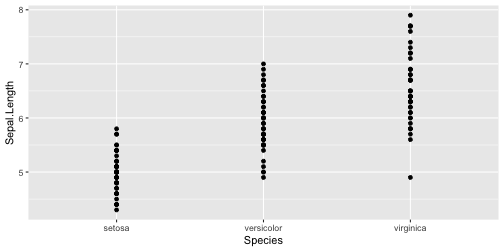

```r
ggplot(iris,
       aes(x = Species, y = Sepal.Length)) +
    geom_point()
```

### ggplot() geom_boxpolt()

用`geom_boxplot()`改畫盒狀圖

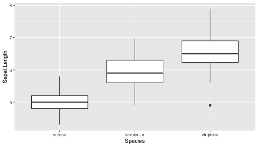

```r
ggplot(iris,
       aes(x = Species,
           y = Sepal.Length)) +
    geom_boxplot()
```

### ggplot() Faceting

**直向分類**~**橫向分類**

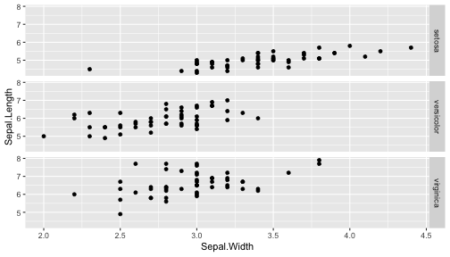

```r
ggplot(iris,
       aes(x = Sepal.Width,
           y = Sepal.Length)) +
    geom_point()+facet_grid(Species~.)
```

### ggplot() Faceting

**直向分類**~**橫向分類**

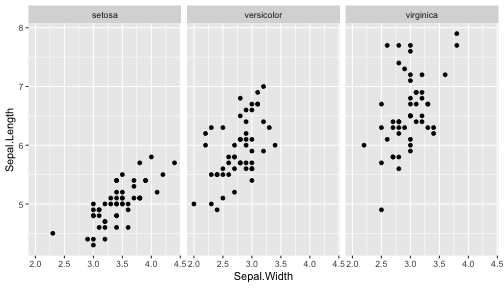

```r
ggplot(iris,
       aes(x = Sepal.Width,
           y = Sepal.Length)) +
    geom_point()+facet_grid(.~Species)
```

### ggplot() geom_smooth()

替xy散佈圖加上趨勢線

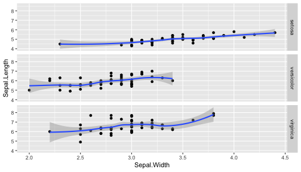

```r
ggplot(iris,
       aes(x = Sepal.Width,
           y = Sepal.Length)) +
    geom_point()+facet_grid(Species~.)+
    geom_smooth()
```

### ggplot() geom_smooth()

替xy散佈圖加上趨勢線，使用linear regresion

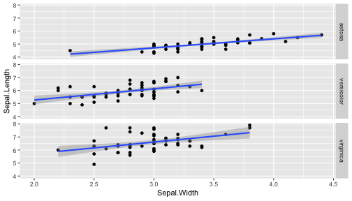

```r
ggplot(iris,
       aes(x = Sepal.Width,
           y = Sepal.Length)) +
    geom_point()+facet_grid(Species~.)+
    geom_smooth(method='lm')
```

### ggplot() geom_line()

改用`geom_line()`畫線

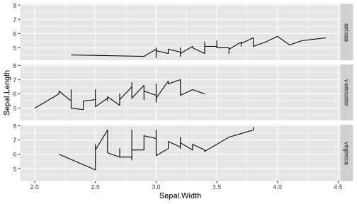

```r
ggplot(iris,
       aes(x = Sepal.Width,
           y = Sepal.Length)) +
    geom_line()+facet_grid(Species~.)
```

### ggplot() 顏色分組

改用顏色分組，使用`aes(color='group name')`

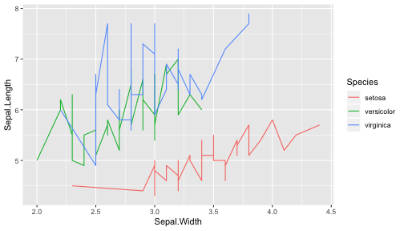

```r
ggplot(iris,
       aes(x = Sepal.Width,
           y = Sepal.Length,
           color=Species)) +
    geom_line()
```

### ggplot() 綜合練習

- 讀入內建iris資料
- 用**ggplot()**畫xy散佈圖
  - x軸：Sepal.Length
  - y軸：Sepal.Width
  - 子圖：Species，每個Species畫在新的**欄位**
- 用**ggplot()**做盒狀圖
  - x軸：Species
  - y軸：Sepal.Width

### ggplot() 注意事項

- 提供資料時，把資料修改為想要在圖片顯示的文字
- 如果是離散性的資料，但卻又是數值時（像是1,2,3）可以用factor()轉換

### ggplot() 資料標示+參數設定

- 標籤 `xlab()`, `ylab()`, `labs(x=,y=)`, `ggtitle()`
- 每一個`geom_*()`都有參數可設定
- 圖形樣式設定 `theme()`，可使用內建樣式
  - `theme_gray()`: 灰背景，預設樣式
  - `theme_bw()`: 黑白樣式
- 使用其他樣式套件
  - `ggthemes` packages [Website](https://cran.r-project.org/web/packages/ggthemes/vignettes/ggthemes.html)
  - `xkcd` packages [Website](http://xkcd.r-forge.r-project.org/)

### ggplot2 參考資料

- [ggplot2 官網](http://ggplot2.tidyverse.org/)
- [ggplot2 package source code](https://github.com/tidyverse/ggplot2)
- [ggplot2 cheat sheet](https://www.rstudio.com/wp-content/uploads/2015/03/ggplot2-cheatsheet.pdf)
- [ggplot2 doc](http://docs.ggplot2.org/)

## ggplot2+地圖

- Choropleth map面量圖
- ggmap()
- Density Map
- 參考資料

### ggmap package

- 把google map載入並作圖的套件
- 基於`ggplot2`套件開發
- 第一次使用前需要安裝

```r
##第一次使用前先安裝
install.packages("ggmap")
```

- `get_googlemap()`函式取得google map圖層
  - center 中心點經緯度座標
  - zoom 放大倍率
  - language 地圖語言
- `ggmap()`函式將取得的圖層畫出來

### get_googlemap() + ggmap()

- 使用`register_google(key = "your key")`帶入google金鑰
- 投影片金鑰已失效，請自行至[Google Cloud Platform](https://console.cloud.google.com/)，點選**API及服務**申請**Maps Static API**後，複製**API key**

[figure not shown]

```r
library(ggmap)
register_google(key = "AIzaSyApRdSUi54irfyfGpYbi8c3fJbP__xzTiY")
twmap <- get_googlemap(center = c(lon=120.58,lat=23.58),
                  zoom = 7,
                  language = "zh-TW")
ggmap(twmap)
```

### ggmap + open data 資料載入

- 只要資料有經緯度等資訊，就可以使用`ggmap` package與各式資料結合呈現
- [台北市水質資料](http://data.taipei/opendata/datalist/apiAccess?scope=resourceAquire&rid=190796c8-7c56-42e0-8068-39242b8ec927)

```r
library(jsonlite)
library(RCurl)
WaterData<-fromJSON("http://data.taipei/opendata/datalist/apiAccess?scope=resourceAquire&rid=190796c8-7c56-42e0-8068-39242b8ec927")
WaterDataFrame<-WaterData$result$results
WaterDataFrame$longitude<-as.numeric(WaterDataFrame$longitude)
WaterDataFrame$latitude<-as.numeric(WaterDataFrame$latitude)
WaterDataFrame$qua_cntu<-as.numeric(WaterDataFrame$qua_cntu)
WaterDataClean<-WaterDataFrame[WaterDataFrame$qua_cntu>=0,]
head(WaterDataClean)
```

```
  update_date update_time qua_ph longitude       qua_id qua_cntu
1  2019-04-13  00:00:00      7.4  121.5694 CS00             0.03
2  2019-04-13  00:00:00      7.3  121.5523 CS01             0.09
3  2019-04-13  00:00:00      7.5  121.5639 CS02             0.12
4  2019-04-13  00:00:00      7.2  121.5444 CS03             0.23
5  2019-04-13  00:00:00      7.3  121.5479 CX00             0.02
6  2019-04-13  00:00:00      7.3  121.5640 CX02             0.06
                 code_name latitude qua_cl _id
1               雙溪淨水場 25.11419   0.51   1
2                 衛理女中 25.10176   0.23   2
3 雙溪國小                 25.10607   0.27   3
4               華興加壓站 25.09952    0.5   4
5               長興淨水場 25.01451   0.56   5
6                 市政大樓 25.03753   0.36   6
```

### ggmap + open data 繪圖

```r
library(ggmap)
TaipeiMap <- get_googlemap(
    center  = c(lon=121.50,lat=25.06),
    zoom = 11, maptype = 'roadmap')
TaipeiMapO <- ggmap(TaipeiMap)+
    geom_point(data=WaterDataClean,
               aes(x=longitude, y=latitude,
                   color=qua_cntu,size=3.5))+
    scale_color_continuous(
        low = "yellow",high = "red")+
    guides(size=FALSE)
TaipeiMapO
```

### ggmap + open data

[figure not shown]

### ggmap + 地圖型態

`ggmap`套件提供多種地圖型態，使用者可透過設定`maptype`自行選擇適合的地圖樣式，樣式有：

- terrain
- terrain-background
- satellite
- roadmap
- hybrid (google maps)
- watercolor
- toner (stamen maps)

### ggmap + extent

透過設定`extent`參數可將地圖輸出樣式改為滿版

```r
library(ggmap)
#extent = 'device' 滿版
ggmap(TaipeiMap,extent = 'device')
```

### ggmap + extent

透過設定`extent`參數可將地圖輸出樣式改為滿版

[figure not shown]

### ggmap() 練習

- 利用get_googlemap() + ggmap()取得桃園地區的google 圖層
  - center = c(lon=121.20,lat=25.00)
  - zoom = 11
  - language = “zh-TW”
- 在長庚大學所在地 （座標121.389539,25.035225）加上一個紅色的點
  - geom_point()
  - x= 121.389539
  - y= 25.035225
  - color =“red”

### ggmap() 練習輸出圖檔

[figure not shown]

### ggmap 參考資料

- [ggmap package source code](https://github.com/dkahle/ggmap)
- [ggmap cheat sheet](https://www.nceas.ucsb.edu/%7Efrazier/RSpatialGuides/ggmap/ggmapCheatsheet.pdf)
- [ggmap doc](https://dl.dropboxusercontent.com/u/24648660/ggmap%20useR%202012.pdf)

### Choropleth map面量圖

- Choropleth map[面量圖](https://en.wikipedia.org/wiki/Choropleth_map)
- **把統計資料用顏色畫在對應的地圖上**
- `choroplethr` package來畫面量圖
- 基於`ggplot2` package的`面量圖`做圖工具
- 建議同時安裝`choroplethrMaps` package

```r
##第一次使用前先安裝
install.packages(c("choroplethr",
                   "choroplethrMaps"))
```

```r
library(choroplethr)
```

### choroplethr package

- 內建美國各州地圖與人口學資料
- 使用`state_choropleth()`函式畫出美國人口分布

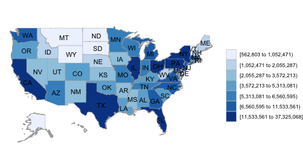

```r
data(df_pop_state) #記載各州人口數的資料
#把各州人口畫在地圖上
state_choropleth(df_pop_state)
```

## Taiwan的面量圖

- 台灣的面量圖尚無好的套件輔助
- Open Data: 台灣鄉鎮市邊界的經緯度檔案
  - [鄉鎮市區界線](http://data.gov.tw/node/7441)
  - 空間資料開放格式`shapefile` `.shp`
- 使用`shapefile`與`ggplot2`畫圖的步驟如下：
  - 取得空間資料檔案
  - 使用`rgdal`, `rgeos`,`maptools` package處理地圖檔shapefile
  - 使用`ggplot2` & `RColorBrewer` 畫圖
- [實作範例網址](http://yijutseng.github.io/DataScienceRBook/vis.html#taiwan)

## Heatmap

- 熱度圖
- 使用顏色的深淺來表示數值的大小
- 搭配XY兩軸的變量
- 使用一張圖就能表示三個維度的資訊
- 在ggplot2套件中，可以使用`geom_tile()`來畫Heatmap
- 以下以NBA球員的資料作為範例

### Heatmap

```r
#讀.csv檔案
nba <- read.csv("http://datasets.flowingdata.com/ppg2008.csv")
head(nba,3)
```

```
           Name  G  MIN  PTS  FGM  FGA   FGP FTM FTA   FTP X3PM X3PA  X3PP
1  Dwyane Wade  79 38.6 30.2 10.8 22.0 0.491 7.5 9.8 0.765  1.1  3.5 0.317
2 LeBron James  81 37.7 28.4  9.7 19.9 0.489 7.3 9.4 0.780  1.6  4.7 0.344
3  Kobe Bryant  82 36.2 26.8  9.8 20.9 0.467 5.9 6.9 0.856  1.4  4.1 0.351
  ORB DRB TRB AST STL BLK  TO  PF
1 1.1 3.9 5.0 7.5 2.2 1.3 3.4 2.3
2 1.3 6.3 7.6 7.2 1.7 1.1 3.0 1.7
3 1.1 4.1 5.2 4.9 1.5 0.5 2.6 2.3
```

### Heatmap

為了做圖，將寬表轉長表

```r
library(reshape2) #for melt()
#寬表轉長表,以名字作依據
nba.m <- melt(nba,id.vars = "Name")
head(nba.m,5)
```

| Name | variable | value |
| --- | --- | --- |
| Dwyane Wade | G | 79 |
| LeBron James | G | 81 |
| Kobe Bryant | G | 82 |
| Dirk Nowitzki | G | 81 |
| Danny Granger | G | 67 |

### geom_tile()

將Geometric objects指定為`geom_tile()`

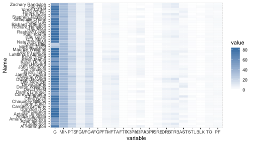

```r
library(ggplot2) #for ggplot()
ggplot(nba.m, aes(variable, Name)) +
    geom_tile(aes(fill = value),
              colour = "white")+
    scale_fill_gradient(
        low = "white",high = "steelblue")
```

### geom_tile() + scale()

- 因為G欄資料明顯大於其他欄位，導致顏色差異不明顯
- 將個欄位的資料標準化處理

```r
#scale處理
library(dplyr)
nba.s<-nba %>%
    mutate_each(funs(scale), -Name)
head(nba.s,2)
```

| Name | G | MIN | PTS | FGM | FGA | FGP | FTM | FTA | FTP | X3PM | X3PA | X3PP | ORB | DRB | TRB | AST | STL | BLK | TO | PF |
| --- | --- | --- | --- | --- | --- | --- | --- | --- | --- | --- | --- | --- | --- | --- | --- | --- | --- | --- | --- | --- |
| Dwyane Wade | 0.6179300 | 1.0019702 | 3.179941 | 2.920022 | 2.596832 | 0.5136017 | 1.917475 | 2.110772 | -0.7401673 | -0.1080044 | 0.1303647 | -0.15749098 | -0.27213551 | -0.3465676 | -0.3287465 | 1.652247 | 2.558238 | 1.2064646 | 1.790445 | -0.2984568 |
| LeBron James | 0.7693834 | 0.6119299 | 2.566974 | 1.957185 | 1.697237 | 0.4649190 | 1.778729 | 1.896589 | -0.5233214 | 0.4920201 | 0.6971679 | 0.02738974 | -0.06117775 | 1.0080940 | 0.6605370 | 1.516147 | 1.367252 | 0.8627425 | 1.059651 | -1.3903719 |

### geom_tile() + scale()

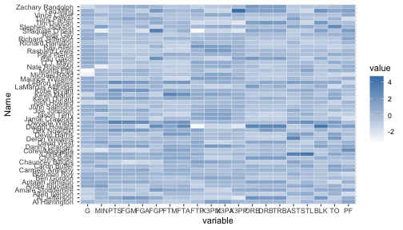

```r
nba.s.m <- melt(nba.s) ##寬轉長
ggplot(nba.s.m, aes(variable, Name)) +
    geom_tile(aes(fill = value),
              colour = "white")+
    scale_fill_gradient(
        low = "white",high = "steelblue")
```

[How to Make a Heatmap – a Quick and Easy Solution](http://flowingdata.com/2010/01/21/how-to-make-a-heatmap-a-quick-and-easy-solution/)

### Heatmap 練習

- 下載[小兒麻痺盛行率](https://raw.githubusercontent.com/CGUIM-BigDataAnalysis/BigDataCGUIM/master/104/POLIO_Incidence.csv)資料
- 將資料載入R
- 表格是寬表，需要轉成長表
- 有缺值 （-），用NA取代
  - 方法一 gsub()
  - 方法二 ifelse()
- 盛行率欄位轉換成數值
  - as.numeric()
- 用年份當x軸，州名當y軸，區塊顏色用盛行率填入
  - low = “white”,high = “steelblue”

## Treemap

- Treemap(矩形式樹狀結構繪圖法)
- 以二維平面的方式展示包含階層結構（hierarchical）形式的統計資訊
- `treemap` packages

### treemap() data

```r
library(treemap)
data(GNI2014)
knitr::kable(head(GNI2014))
```

|  | iso3 | country | continent | population | GNI |
| --- | --- | --- | --- | --- | --- |
| 3 | BMU | Bermuda | North America | 67837 | 106140 |
| 4 | NOR | Norway | Europe | 4676305 | 103630 |
| 5 | QAT | Qatar | Asia | 833285 | 92200 |
| 6 | CHE | Switzerland | Europe | 7604467 | 88120 |
| 7 | MAC | Macao SAR, China | Asia | 559846 | 76270 |
| 8 | LUX | Luxembourg | Europe | 491775 | 75990 |

### treemap()

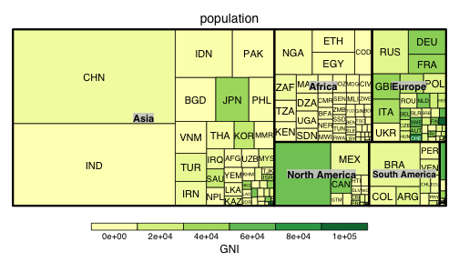

```r
library(treemap)
data(GNI2014)
treemap(GNI2014,
       index=c("continent", "iso3"), #分組依據
       vSize="population", #區塊大小
       vColor="GNI", #顏色深淺
       type="value")
```

### 互動式資料呈現

- [互動式資料呈現](http://yijutseng.github.io/DataScienceRBook/InteractiveGraphics.html)
- ggvis
- [googleVis](http://yijutseng.github.io/DataScienceRBook/InteractiveGraphics.html#googlevis)
- [Plot.ly](http://yijutseng.github.io/DataScienceRBook/InteractiveGraphics.html#plot.ly)

## 參考資料

- 官方網站[文件](http://docs.ggplot2.org/current/)
- RStudio製作的[ggplot cheat sheet](https://www.rstudio.com/wp-content/uploads/2016/11/ggplot2-cheatsheet-2.1.pdf)
- DataCamp課程1 [Data Visualization with ggplot2 (Part 1)](https://www.datacamp.com/courses/data-visualization-with-ggplot2-1)
- DataCamp課程2 [Data Visualization with ggplot2 (Part 2)](https://www.datacamp.com/courses/data-visualization-with-ggplot2-2)
- DataCamp課程3 [Data Visualization with ggplot2 (Part 3)](https://www.datacamp.com/courses/data-visualization-with-ggplot2-3)
- [每個人心中都有一碗巷口的牛肉湯](http://tequila1979.blogspot.tw/2017/01/blog-post.html)